# Join us in Todos Santos!

Please join us for our computational biology workshop at the CSU Center in Todos Santos, Mexico. Here is a summary of the topics that we are looking forward to covering over the course of the week.

## Computational Workshop

### Instructors: Kim Hoke, Tai Montgomery, Dan Sloan, Mark Stenglein

### Monday May 9: Introduction to high-throughput sequencing, computational biology, and code management

- **09:00-09:30** Arrival and Check-In
- **09:30-10:30** Introduction to Todos Santos and Group Discussion [[**slides**]](https://github.com/taimontgomery/TodosSantos2022/blob/main/TodosSantosIntroduction2022.pdf)
- **10:30-12:00** High-Throughput Sequencing Technologies [[**slides**]](https://github.com/taimontgomery/TodosSantos2022/blob/main/TodosSantosHTS2022.pdf)
- **12:00-13:00** Lunch
- **13:00-14:30** [UNIX and Command Line Tools (part I)](https://taimontgomery.github.io/Linux/) [[**slides**]](https://github.com/taimontgomery/TodosSantos2022/blob/main/TodosSantosLinux2022.pdf)
- **14:30-16:00** [UNIX and Command Line Tools (part II)](https://taimontgomery.github.io/Bash/) [**UNIX commands sheet**]
- **16:00-17:00** [Workflow Manangement (Snakemake)](https://taimontgomery.github.io/Snakemake/) [[**slides**]](https://github.com/taimontgomery/TodosSantos2022/blob/main/TodosSantosWorkflows2022.pdf)

### Tuesday May 10: RNA-seq

- **08:00-08:45** Breakfast
- **09:00-12:00** [RNA-seq Data Analysis I](https://taimontgomery.github.io/Trinity/) [[**slides**]](https://github.com/taimontgomery/TodosSantos2022/blob/main/TodosSantosRNAseq2022.pdf)
- **12:00-13:00** Lunch
- **13:00-17:00** RNA-seq Data Analysis II

### Wednesday May 11: Genomic analysis tools

- **08:00-08:45** Breakfast
- **09:00-10:00** Introduction to Genomic Analysis [**slides**]
- **10:00-12:00** [Manipulating and Obtaining Genomics Data](https://github.com/stenglein-lab/2022_Todos_Santos/blob/main/exercises/metagenomics_exercise.md) [**slides**]
- **12:00-13:00** Lunch
- **13:00-14:30** Alignment and Read Mapping [**slides**]
- **14:30-16:00** Assembly and Annotation [**slides**]
- **16:00-17:00** [Variant Calling](https://github.com/stenglein-lab/2022_Todos_Santos/blob/main/exercises/variant_exercise.md)
- **18:00-20:00** Workshop Dinner

### Thursday May 12: Data Visualization

- **08:00-08:45** Breakfast
- **09:00-10:00** [Code Management (GitHub)](https://dbsloan.github.io/TS2022/exercises/github.html)
- **10:00-10:30** Introduction to R, R Markdown, and Data Visualization [**slides**]
- **10:30-12:00** Plotting Genomic Data with R and ggplot
- **12:00-13:00** Lunch
- **13:00-14:00** Figure Drawing in R
- **14:00-15:00** Circular Representations of Genomic Data with Circos
- **15:00-16:00** Local BLAST and Comparative Genomics [**slides**]
- **16:00** End of workshop

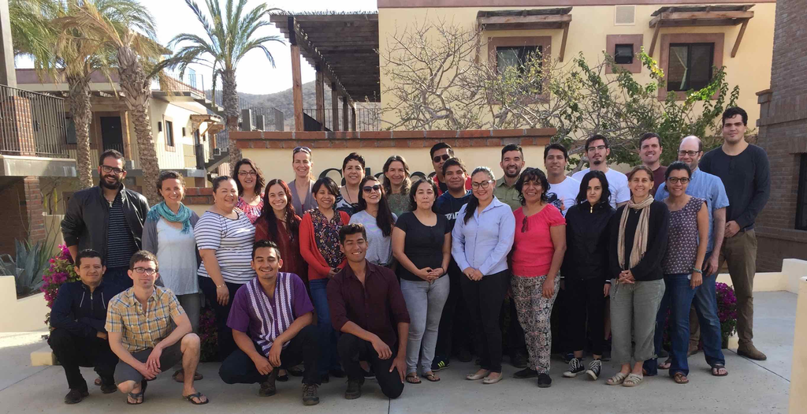

[figure not shown]

Supported by the the National Science Foundation and Colorado State University